# Rscience - _script_modulo

Detallamos en un formato más estético nuestra tabla con los 5 casos.  
La fila que corresponde a nuestro caso de análisis será en color.

[output not shown]

**Selected case**

Detallamos en un formato más estético solo el caso de análisis que se aplica a nuestros datos.

| Statistic.Case | All.requeriments.OK | Anova.rejected | Tukey.at.least.2.groups | Tukey_Decision |
| --- | --- | --- | --- | --- |
| Case 1 | No | No/Yes | No/Yes | La utilización del test de Tukey está supeditada a la validez del modelo de Anova y al rechazo de la hipótesis de anova. Al no se cumplen los requisitos del modelo no es válido el test de Anova y por … |

**ASA**

Temática 4) Tukey

| Statistic.Case | All.requeriments.OK | Anova.rejected | Tukey.at.least.2.groups | Decision |
| --- | --- | --- | --- | --- |
| Case 1 | No | No/Yes | No/Yes | Decision Case 1 |

La utilización del test de Tukey está supeditada a la validez del modelo de Anova y al rechazo de la hipótesis de anova. Al no se cumplen los requisitos del modelo no es válido el test de Anova y por lo tanto tampoco es válido el test de Tukey. La información relacionada al test de Tukey debe ser descartada. Como ya se ha detallado antes, en este contexto continuar con la interpretación estadística es un error estadístico grave que manifiesta un desconocimiento total del criterios estadísticos para tomar decisiones.

```r
# 1. Identificar objetos esenciales para CADA reporte
objetos_reporte_word <- c("df_summary_anova")
objetos_reporte_excel <- c("df_summary_anova")

# 2. Guardar por lote específico
save(list = objetos_reporte_word, file = "output_folder/reporte_word_objetos.RData")
save(list = objetos_reporte_excel, file = "output_folder/reporte_excel_objetos.RData")
```

```r
# 1. Cargar la librería (asegúrate de que esté instalada)
library(writexl)

# 2. Crear los tres dataframes de ejemplo (Tus df_summary_anova, etc.)
df_anova_model <- data.frame(
  Source = c("A", "Error"),
  DF = c(1, 18),
  SS = c(100.5, 95.3)
)

df_posthoc_tests <- data.frame(
  Comparison = c("Group 1 vs 2", "Group 2 vs 3"),
  Mean_Diff = c(5.2, 1.1),
  P_Value = c(0.001, 0.45)
)

df_summary_stats <- data.frame(
  Group = c("G1", "G2", "G3"),
  Mean = c(15.2, 20.4, 21.5),
  SD = c(2.1, 1.8, 2.5)
)

# 3. Crear una lista con los dataframes
# NOTA CLAVE: El nombre que le asignes a cada elemento de la lista
# será el nombre de la pestaña en el archivo Excel.
list_of_dataframes <- list(
  "ANOVA_Modelo" = df_anova_model,
  "Pruebas_PostHoc" = df_posthoc_tests,
  "Estadisticas_Descriptivas" = df_summary_stats
)

# 4. Definir el nombre del archivo
file_name_xlsx <- paste0("report_02_anova_1_way.xlsx")
subfolder_output <- "output_folder"
dir.create(subfolder_output, recursive = TRUE)
file_path_xlsx <- file.path(subfolder_output, file_name_xlsx)

# 5. Guardar la lista de dataframes en el archivo Excel
# Cada elemento de la lista se convierte en una hoja de cálculo.
writexl::write_xlsx(
  x = list_of_dataframes,
  path = file_path_xlsx
)

cat(paste0("Se han guardado 3 dataframes en el archivo '", file_name, "' con tres pestañas diferentes."))
```

[output not shown]

```r
   quarto::quarto_render(input = "save_word.qmd",
                            output_format = "docx",
                            output_file = "report_03_anova_1_way.docx",
                            quiet = FALSE)
```

```
pandoc
  to: docx
  output-file: report_03_anova_1_way.docx
  default-image-extension: png
  toc: true
  toc-depth: 2
  number-sections: true

metadata
  title: ANOVA Statistical Report
  author: Data Analysis Team
  date: '`r format(Sys.Date(), ''%B %d, %Y'')`'
  output-file: report_03_anova_1_way.docx

Output created: report_03_anova_1_way.docx
```

```r
  file.rename(from = "report_03_anova_1_way.docx",
            to = "output_folder/report_03_anova_1_way.docx")
```

```
[1] TRUE
```

```r
   quarto::quarto_render(input = "save_word.qmd",
                            output_format = "pdf",
                            output_file = "report_04_anova_1_way.pdf",
                            quiet = FALSE)
```

[output not shown]

```r
  file.rename(from = "report_04_anova_1_way.pdf",
            to = "output_folder/report_04_anova_1_way.pdf")
```

```
[1] TRUE
```

**Init**

## Summary software

- **Operating System:** Ubuntu 22.04.5 LTS
- **Platform info:** x86_64-pc-linux-gnu
- **R Info:** R version 4.4.3 (2025-02-28) – “Trophy Case”
- **Rscience Version:** Rscience 1.0.13
- **UTC Time:** 2025-11-21 22:55:55 UTC
- **System/Computer Time:** 2025-11-21 23:55:55 CET
- **Inferred Timezone Location:** Europe/Rome  
  (R can only reliably determine the timezone, not the physical city/country.)

## User Inputs

- **Rscience Tool:** General Linear Model - Fixed Effect - Balanced Tratments - Anova - Anova 1 Way
- **Rscience Tool Script:** Script XXX-001
- **Data source:** r_source
- **Dataset file name:** mtcars
- **Response Variable:** mpg
- **Factor:** cyl
- **Alpha value:** 0.05

**AutoReport**

## Report (Automated Statistical Assistant)

The null hypothesis of normal distribution of residuals is not rejected.

The hypothesis of homogeneity of variances (homoscedasticity) is rejected.

Not all requirements for the model are met.

It is NOT valid to draw conclusions from the ANOVA test.

Al no cumplirse los requisitos del modelo debe descartarse el análisis de Anova y Tukey indistintamente de los valores estadísticos obtenidos. Se detalla a continuación la interpretación literal y descontextualizada del test de Anova y el test de Tukey solo a fines demostrativos, pero sin ninguna validez para obtener conclusiones a partir de ellos.

The null hypothesis of the ANOVA test is rejected. There are statistically significant differences in at least one level of the factor.

Al ser rechazada la hipótesis nula de Anova, es válida la utilización de un test de comparaciones múltiple que acompañe al test de Anova.

Es seleccionado el test de Tukey como test de comparaciones múltiple para este script.

El test de Tukey indica que existen al menos 2 grupos entre los niveles del factor. Cantidad de grupos y estructura debe ser analizada en detalle con la tabla de Tukey.

### 1) Summary Anova

| name | test | variable | p_value | alpha_value | Decision | Valid |
| --- | --- | --- | --- | --- | --- | --- |
| Shapiro-Wilk test | Normality | residuals | 0.5176650 | 0.05 | Ho no rejected | Yes, it is. |
| Bartlett test | Homogeneity | residuals | 0.0150452 | 0.05 | Ho Rejected | Yes, it is. |
| Anova 1 way | Analysis of Variance | mpg | 0.0000000 | 0.05 | Ho Rejected | No, is not!!! |
| Tukey | Mean groups | mpg | NA | 0.05 | At least two groups of means. | No, is not!!! |

### 2) Plot means and standard error from model

[interactive chart not shown]

### 3) Tukey table

| order | level | mean | group |
| --- | --- | --- | --- |
| 1 | 4 | 26.66364 | a |
| 2 | 6 | 19.74286 | b |
| 3 | 8 | 15.10000 | c |

**Theory**

The most important statistical output from Anova as R formatted objects.

**Model**

The one-way ANOVA model can be expressed in two equivalent forms:

### Form 1: Treatment Effects Model

$$Y_{ij} = \mu + \tau_i + \varepsilon_{ij}$$

### Form 2: Group Means Model

$$Y_{ij} = \mu_i + \varepsilon_{ij}$$

### Model Components

**Where:** - $Y_{ij}$ = $j$-th observation in the $i$-th group - $\mu$ = Overall mean (grand mean) - $\tau_i$ = Effect of the $i$-th treatment - $\mu_i$ = Mean of the $i$-th group - $\varepsilon_{ij}$ = Random error term

### Key Relationship

The relationship between the two formulations is given by:

$$\mu_i = \mu + \tau_i$$

### Model Parameters

- $k$ = number of groups or treatments
- $\mu_i$ = population mean of group $i$
- $i = 1, 2, \ldots, k$ (group index)
- $j = 1, 2, \ldots, n_i$ (observation index within each group)
- $n_i$ = number of observations in group $i$

### Error Term Specification

The random error term follows a normal distribution:

$$\varepsilon_{ij} \sim N(0, \sigma^2)$$

**Where:** - $\sigma^2$ = common variance across all groups

### Summary One-Way ANOVA Model

Every general linear model involves estimating parameters for a polynomial in order to predict a quantitative response variable with special requirements of normality, homogeneity of variances, and independence of residuals.

The fixed effects general linear model of One-Way ANOVA involves:

- The response variable or dependent variable must be quantitative.
- The predictor variable must be a qualitative independent variable with at least 2 levels. Particularly in ANOVA models, this variable is called a Factor.
- The expected component of the model arises from estimating zero-degree polynomials, one for each factor level. Estimating the means of each factor level involves estimating the intercept term of a zero-degree polynomial.
- The error component must have a normal distribution, zero mean, homogeneous variance, and the residuals must be independent.
- The normality test is performed using the Shapiro-Wilk test.
- Homogeneity is formally tested using Bartlett’s test.
- Independence concerns the errors. Errors are independent if the statistical units are independent. Statistical units are independent if the design is carried out under this concept. Independence is a required characteristic in the design and cannot be tested in any way.

**Hypothesis**

### Statistical Hypotheses

#### Form 1: Treatment Effects ($\tau_i$)

| Hypothesis Type | Mathematical Formulation | Verbal Description |
| --- | --- | --- |
| **Null Hypothesis ($H_0$)** | $H_0: \tau_1 = \tau_2 = \cdots = \tau_k = 0$ | All treatment effects are zero |
| **Alternative Hypothesis ($H_1$)** | $H_1: \exists\; i \in \{1,2,\ldots,k\} \mid \tau_i \neq 0$ | At least one treatment effect is different from zero |

#### Form 2: Group Means ($\mu_i$)

| Hypothesis Type | Mathematical Formulation | Verbal Description |
| --- | --- | --- |
| **Null Hypothesis ($H_0$)** | $H_0: \mu_1 = \mu_2 = \cdots = \mu_k$ | All group means are equal |
| **Alternative Hypothesis ($H_1$)** | $H_1: \exists\; i,j \in \{1,2,\ldots,k\} \mid i \neq j \land \mu_i \neq \mu_j$ | At least one group mean is different |

### Assumption Tests for ANOVA Residuals

#### Normality Test (e.g., Shapiro-Wilk)

| Hypothesis Type | Mathematical Formulation | Verbal Description |
| --- | --- | --- |
| **Null Hypothesis ($H_0$)** | $H_0: \varepsilon_{ij} \sim N(0, \sigma^2)$ | The residuals are normally distributed |
| **Alternative Hypothesis ($H_1$)** | $H_1: \varepsilon_{ij} \not\sim N(0, \sigma^2)$ | The residuals are not normally distributed |

#### Homogeneity of Variances Test (e.g., Bartlett’s Test)

| Hypothesis Type | Mathematical Formulation | Verbal Description |
| --- | --- | --- |
| **Null Hypothesis ($H_0$)** | $H_0: \sigma_1^2 = \sigma_2^2 = \cdots = \sigma_k^2$ | All group variances are equal |
| **Alternative Hypothesis ($H_1$)** | $H_1: \exists\; i,j \in \{1,2,\ldots,k\} \mid i \neq j \land \sigma_i^2 \neq \sigma_j^2$ | At least one group variance is different |

### Decision Rule

The decision to reject or not reject the null hypothesis is based on the p-value and the significance level $\alpha$:

$$\text{If } p < \alpha \Rightarrow \text{Reject } H_0$$

$$\text{If } p \geq \alpha \Rightarrow \text{Fail to reject } H_0$$

**Where:** - $p$ = p-value from the statistical test - $\alpha$ = significance level (typically 0.05) - $k$ = number of groups or treatments - $\sigma_i^2$ = variance of group $i$ - $\exists$ = “there exists” (existential quantifier)

**Decision Plan**

### Decision-Making Process in ANOVA

The ANOVA test is specifically performed to make decisions.  
The decision-making process has a set of sequential steps, in a particular order.  
- Step 01: Control over the response variable.  
- Step 02: Verification of the normality requirement of the residuals.  
- Step 03: Verification of the homogeneity of variances requirement.  
- Step 04: Interpretation of the ANOVA test.  
- Step 05: Interpretation of the Tukey test.

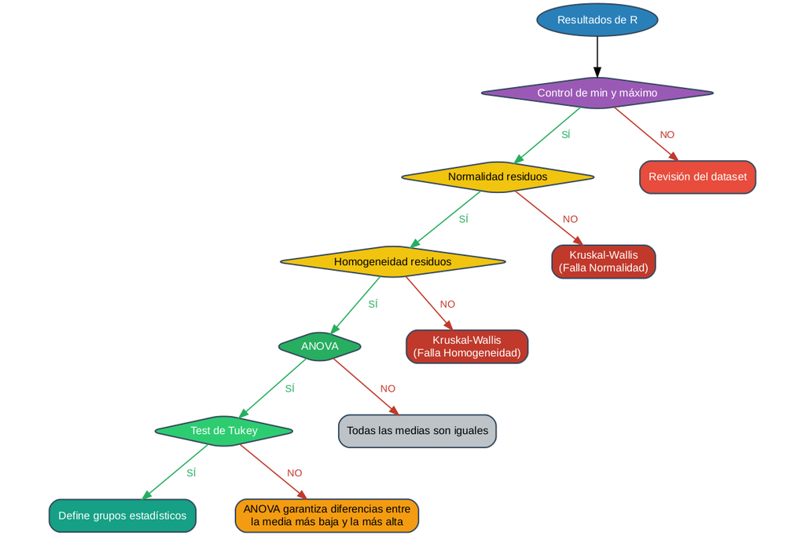

🔍 Haz clic en la imagen para ver en tamaño completo

### Possible Analysis Cases

Decision-making in One-Way ANOVA involves 5 steps.  
Each step has 2 possibilities: Yes or No.  
This implies that for a given dataset, the analysis can lead to one of 2^5 = 32 possibilities.  
Fortunately, these 32 possibilities can be summarized into 6 analysis cases.  
Any dataset falls into one of these cases, and this implies at least the possibility of providing a general statistical interpretation of what happens to that dataset.

| Caso | Control.OK | Normalidad.not.rejected | Homogeneidad.not.rejected | Anova.rejected | Tukey.at.least.2.groups | Decision |
| --- | --- | --- | --- | --- | --- | --- |
| Case 1 | No | No/Yes | No/Yes | No/Yes | No/Yes | If it is certain that the minimum and/or maximum value do not correspond to possible values of the variable, the possibility of statistical analysis is immediately ruled out until (if possible) a veri… |
| Case 2 | Yes | No | No/Yes | No/Yes | No/Yes | When the normality requirement of the residuals is not met, the use of the One-Way ANOVA test on the dataset is immediately ruled out. In this context, continuing to interpret statistical values is a … |
| Case 3 | Yes | Yes | No | No/Yes | No/Yes | When the homogeneity requirement of the residuals is not met, the use of the One-Way ANOVA test on this dataset is immediately ruled out. In this context, continuing to interpret statistical values is… |
| Case 4 | Yes | Yes | Yes | No | No/Yes | All requirements are met. It is valid to interpret the ANOVA p-value. The conclusions obtained from ANOVA are valid. The null hypothesis of ANOVA is not rejected. All means are statistically equal. Th… |
| Case 5 | Yes | Yes | Yes | Yes | No | All ANOVA requirements are met. It is valid to interpret the ANOVA p-value. The conclusions obtained from ANOVA are valid. The null hypothesis of ANOVA is rejected. There is at least one different mea… |
| Case 6 | Yes | Yes | Yes | Yes | Yes | All ANOVA requirements are met. The conclusions obtained from ANOVA are valid. The null hypothesis of ANOVA is rejected. There is at least one different mean. The differences between the means are not… |

**Bibliografy**

**ClassRoom**

The most important statistical output from Anova as R formatted objects.

**User election**

### Selected variable and rol

| order | var_name | var_number | var_letter | var_role | doble_reference |
| --- | --- | --- | --- | --- | --- |
| 1 | mpg | 1 | A | RV | RV(mpg) |
| 2 | cyl | 2 | B | FACTOR | FACTOR(cyl) |

### Alpha and confidence values

| order | detail | probability | percentaje |
| --- | --- | --- | --- |
| 1 | alpha value | 0.05 | 5% |
| 2 | confidence value | 0.95 | 95% |

### Amount of data to analysis

| object | n_col | n_row |
| --- | --- | --- |
| my_dataset | 11 | 32 |
| minidataset | 2 | 32 |

**Anova Table**

### 1) Anova Table (Class Room format)

This is the table format detailed in the bibliography.

|  | Sources of Variation | Df | Sum Sq | Mean Sq | F value | Pr(>F) |
| --- | --- | --- | --- | --- | --- | --- |
| cyl | Factor | 2 | 824.7846 | 412.39229 | 39.69752 | 0 |
| Residuals | Error | 29 | 301.2626 | 10.38837 | NA | NA |
| Total | Total | 31 | 1126.0472 | 36.32410 | NA | NA |

### 2) Anova Table (R format)

The original R output does not contain the Source of Variation column, and it does not detail the row for the total source of variation.

|  | Df | Sum Sq | Mean Sq | F value | Pr(>F) |
| --- | --- | --- | --- | --- | --- |
| cyl | 2 | 824.7846 | 412.39229 | 39.69752 | 0 |
| Residuals | 29 | 301.2626 | 10.38837 | NA | NA |

**Tukey Test**

### 1) Tukey Test (Class Room format)

This is the table format detailed in the bibliography.

| order | level | mean | group |
| --- | --- | --- | --- |
| 1 | 4 | 26.66364 | a |
| 2 | 6 | 19.74286 | b |
| 3 | 8 | 15.10000 | c |

### 2) Special plot for Tukey test

The means of each factor level are detailed with the standard error derived from the model.  
The statistical groups from the Tukey test are detailed for each factor level.

[interactive chart not shown]

### 3) Full info from Tukey (R format)

The Tukey table is only one part of all the information contained within the Tukey test.  
The Tukey test contains more details that may be relevant, such as the honest significant difference (HSD).

```
$statistics
   MSerror Df     Mean      CV
  10.38837 29 20.09062 16.0428

$parameters
   test name.t ntr StudentizedRange alpha
  Tukey    cyl   3         3.492609  0.05

$means
       mpg      std  r        se  Min  Max   Q25  Q50   Q75
4 26.66364 4.509828 11 0.9718008 21.4 33.9 22.80 26.0 30.40
6 19.74286 1.453567  7 1.2182168 17.8 21.4 18.65 19.7 21.00
8 15.10000 2.560048 14 0.8614094 10.4 19.2 14.40 15.2 16.25

$comparison
NULL

$groups
       mpg groups
4 26.66364      a
6 19.74286      b
8 15.10000      c

attr(,"class")
[1] "group"
```

### 4) Pairs comparation from Tukey test (R format)

Internally, the Tukey test performs t-tests between all possible pairs of factor levels.  
In each t-test, a p-value is obtained with which decisions are made. All pairs are detailed below.

```
$statistics
   MSerror Df     Mean      CV
  10.38837 29 20.09062 16.0428

$parameters
   test name.t ntr StudentizedRange alpha
  Tukey    cyl   3         3.492609  0.05

$means
       mpg      std  r        se  Min  Max   Q25  Q50   Q75
4 26.66364 4.509828 11 0.9718008 21.4 33.9 22.80 26.0 30.40
6 19.74286 1.453567  7 1.2182168 17.8 21.4 18.65 19.7 21.00
8 15.10000 2.560048 14 0.8614094 10.4 19.2 14.40 15.2 16.25

$comparison
      difference pvalue signif.      LCL       UCL
4 - 6   6.920779 0.0001     *** 3.330308 10.511251
4 - 8  11.563636 0.0000     *** 7.973165 15.154108
6 - 8   4.642857 0.0092      ** 1.052385  8.233329

$groups
NULL

attr(,"class")
[1] "group"
```

**Requeriments**

### 1) Requeriment - Normaility test - Residuals (R format)

| variable | test | statistic(W) | p_value |
| --- | --- | --- | --- |
| residuals | Shapiro-Wilk normality test | 0.9706547 | 0.517665 |

### 2) Requeriment - Homogeneity test - Residuals (R format)

| variable | test | statistic(Bartlett's K-squared) | p_value |
| --- | --- | --- | --- |
| residuals | Bartlett test of homogeneity of variances | 8.393396 | 0.0150452 |

### 3) Estimated variances - Residuals

| order | level | n | model_error_var_MSE | model_error_sd | model_error_se | raw_error_se |
| --- | --- | --- | --- | --- | --- | --- |
| 1 | 6 | 7 | 10.38837 | 3.223099 | 1.2182168 | 1.2182168 |
| 2 | 4 | 11 | 10.38837 | 3.223099 | 0.9718008 | 0.9718008 |
| 3 | 8 | 14 | 10.38837 | 3.223099 | 0.8614094 | 0.8614094 |

| order | level | n | raw_error_var | raw_error_sd |
| --- | --- | --- | --- | --- |
| 1 | 6 | 7 | 2.112857 | 1.453567 |
| 2 | 4 | 11 | 20.338545 | 4.509828 |
| 3 | 8 | 14 | 6.553846 | 2.560048 |

Anova and Tukey use MSE from model with ‘n-k’ degree of freedom. Bartlett use variance from raw error on each level with ‘n_i’ defree of freedom on each level. Only if there is homogeneity from raw error variances then is a good idea take decision from MSE in Anova and Tukey.

**Plots - Raw Data**

[interactive chart not shown]

|  | order | level | n | mean | min | max | sd | var |
| --- | --- | --- | --- | --- | --- | --- | --- | --- |
| 6 | 1 | 6 | 7 | 19.74286 | 17.8 | 21.4 | 1.453567 | 2.112857 |
| 4 | 2 | 4 | 11 | 26.66364 | 21.4 | 33.9 | 4.509828 | 20.338545 |
| 8 | 3 | 8 | 14 | 15.10000 | 10.4 | 19.2 | 2.560048 | 6.553846 |

[interactive chart not shown]

|  | order | level | n | mean | model_error_sd | lower_limit | upper_limmit | color |
| --- | --- | --- | --- | --- | --- | --- | --- | --- |
| 6 | 1 | 6 | 7 | 19.74286 | 3.223099 | 16.51976 | 22.96596 | #000000 |
| 4 | 2 | 4 | 11 | 26.66364 | 3.223099 | 23.44054 | 29.88674 | #00FF00 |
| 8 | 3 | 8 | 14 | 15.10000 | 3.223099 | 11.87690 | 18.32310 | #0000FF |

[interactive chart not shown]

|  | order | level | n | mean | model_error_se | lower_limit | upper_limmit | color |
| --- | --- | --- | --- | --- | --- | --- | --- | --- |
| 6 | 1 | 6 | 7 | 19.74286 | 1.2182168 | 18.52464 | 20.96107 | #000000 |
| 4 | 2 | 4 | 11 | 26.66364 | 0.9718008 | 25.69184 | 27.63544 | #00FF00 |
| 8 | 3 | 8 | 14 | 15.10000 | 0.8614094 | 14.23859 | 15.96141 | #0000FF |

[interactive chart not shown]

| order_level | level | n | variable | min | mean | Q1 | median | Q3 | max | color |
| --- | --- | --- | --- | --- | --- | --- | --- | --- | --- | --- |
| 1 | 6 | 7 | mpg | 17.8 | 19.74286 | 18.65 | 19.7 | 21.00 | 21.4 | #000000 |
| 2 | 4 | 11 | mpg | 21.4 | 26.66364 | 22.80 | 26.0 | 30.40 | 33.9 | #00FF00 |
| 3 | 8 | 14 | mpg | 10.4 | 15.10000 | 14.40 | 15.2 | 16.25 | 19.2 | #0000FF |

[interactive chart not shown]

| order_level | level | n | variable | min | mean | Q1 | median | Q3 | max | color |
| --- | --- | --- | --- | --- | --- | --- | --- | --- | --- | --- |
| 1 | 6 | 7 | mpg | 17.8 | 19.74286 | 18.65 | 19.7 | 21.00 | 21.4 | #000000 |
| 2 | 4 | 11 | mpg | 21.4 | 26.66364 | 22.80 | 26.0 | 30.40 | 33.9 | #00FF00 |
| 3 | 8 | 14 | mpg | 10.4 | 15.10000 | 14.40 | 15.2 | 16.25 | 19.2 | #0000FF |

[interactive chart not shown]

| order_level | level | n | variable | min | mean | Q1 | median | Q3 | max | color |
| --- | --- | --- | --- | --- | --- | --- | --- | --- | --- | --- |
| 1 | 6 | 7 | mpg | 17.8 | 19.74286 | 18.65 | 19.7 | 21.00 | 21.4 | #000000 |
| 2 | 4 | 11 | mpg | 21.4 | 26.66364 | 22.80 | 26.0 | 30.40 | 33.9 | #00FF00 |
| 3 | 8 | 14 | mpg | 10.4 | 15.10000 | 14.40 | 15.2 | 16.25 | 19.2 | #0000FF |

[interactive chart not shown]

[output not shown]

**Plots - Residuals**

[interactive chart not shown]

|  | order | level | n | min | mean | max | var | sd | color |
| --- | --- | --- | --- | --- | --- | --- | --- | --- | --- |
| 6 | 1 | 6 | 7 | -1.942857 | 0 | 1.657143 | 2.112857 | 1.453567 | #000000 |
| 4 | 2 | 4 | 11 | -5.263636 | 0 | 7.236364 | 20.338545 | 4.509828 | #00FF00 |
| 8 | 3 | 8 | 14 | -4.700000 | 0 | 4.100000 | 6.553846 | 2.560048 | #0000FF |

[interactive chart not shown]

|  | order | level | n | min | mean | max | var | sd | color |
| --- | --- | --- | --- | --- | --- | --- | --- | --- | --- |
| 6 | 1 | 6 | 7 | -1.942857 | 0 | 1.657143 | 2.112857 | 1.453567 | #000000 |
| 4 | 2 | 4 | 11 | -5.263636 | 0 | 7.236364 | 20.338545 | 4.509828 | #00FF00 |
| 8 | 3 | 8 | 14 | -4.700000 | 0 | 4.100000 | 6.553846 | 2.560048 | #0000FF |

[interactive chart not shown]

|  | order | level | n | min | mean | max | var | sd | color |
| --- | --- | --- | --- | --- | --- | --- | --- | --- | --- |
| 6 | 1 | 6 | 7 | -1.942857 | 0 | 1.657143 | 2.112857 | 1.453567 | #000000 |
| 4 | 2 | 4 | 11 | -5.263636 | 0 | 7.236364 | 20.338545 | 4.509828 | #00FF00 |
| 8 | 3 | 8 | 14 | -4.700000 | 0 | 4.100000 | 6.553846 | 2.560048 | #0000FF |

[interactive chart not shown]

| variable | n | min | mean | max | var | sd | model_error_var_MSE | model_error_sd |
| --- | --- | --- | --- | --- | --- | --- | --- | --- |
| residuals | 32 | -5.263636 | 0 | 7.236364 | 9.718148 | 3.117395 | 10.38837 | 3.223099 |

[interactive chart not shown]

| variable | n | min | mean | max | var | sd | model_error_var_MSE | model_error_sd |
| --- | --- | --- | --- | --- | --- | --- | --- | --- |
| residuals | 32 | -5.263636 | 0 | 7.236364 | 9.718148 | 3.117395 | 10.38837 | 3.223099 |

[interactive chart not shown]

|  | order | level | n | min | mean | max | var | sd | color |
| --- | --- | --- | --- | --- | --- | --- | --- | --- | --- |
| 6 | 1 | 6 | 7 | -0.6027917 | 0 | 0.5141459 | 0.2033869 | 0.4509843 | #000000 |
| 4 | 2 | 4 | 11 | -1.6330981 | 0 | 2.2451573 | 1.9578196 | 1.3992211 | #00FF00 |
| 8 | 3 | 8 | 14 | -1.4582240 | 0 | 1.2720678 | 0.6308833 | 0.7942816 | #0000FF |

[interactive chart not shown]

|  | order | level | n | min | mean | max | var | sd | color |
| --- | --- | --- | --- | --- | --- | --- | --- | --- | --- |
| 6 | 1 | 6 | 7 | -0.6027917 | 0 | 0.5141459 | 0.2033869 | 0.4509843 | #000000 |
| 4 | 2 | 4 | 11 | -1.6330981 | 0 | 2.2451573 | 1.9578196 | 1.3992211 | #00FF00 |
| 8 | 3 | 8 | 14 | -1.4582240 | 0 | 1.2720678 | 0.6308833 | 0.7942816 | #0000FF |

[interactive chart not shown]

| variable | n | min | mean | max | var | sd |
| --- | --- | --- | --- | --- | --- | --- |
| studres | 32 | -1.633098 | 0 | 2.245157 | 0.9354839 | 0.9672042 |

[interactive chart not shown]

| variable | n | min | mean | max | var | sd |
| --- | --- | --- | --- | --- | --- | --- |
| studres | 32 | -1.633098 | 0 | 2.245157 | 0.9354839 | 0.9672042 |

[interactive chart not shown]

| variable | n | min | mean | max | var | sd |
| --- | --- | --- | --- | --- | --- | --- |
| studres | 32 | -1.633098 | 0 | 2.245157 | 0.9354839 | 0.9672042 |

**FAQs**

En esta sección se dan un conjunto de preguntas tanto desde el punto de vista estadístico, informático o del diseño. Las preguntas y respuestas están mezcladas en su temática.

### 2) ¿Es lo mismo variable numérica que variable cuantitativa?.

Rta: Es un error muy común. No. No es lo mismo. Una variable es numérica desde el punto de vista informático si la variable es representada con símbolos numéricos dentro del dataset. Si yo tengo una variable que tiene categorías representada con números entonces la variable no es numérica. Una variable cualitativa ordinal representada con números, como por ejemplo escala de dolor, índice de felicidad, cobertura de suelo determinada a ojo del operador, cuanto me gusta el helado de chocolate del 1 al 10, no son variable cuantitativas.

Si la variable respuesta es cualitativa nominal representada con números o cualitativa ordinal representada con números, en ambos casos la variable es numérica pero no es cuantitativa. En esos casos ingresar al test de Anova es un error grave. El test de Anova es solo para variables cuantitativas. Si se tiene un factor y una variable respuesta cualitativa nominal representada con números, debiera tal vez realizarse un test Chi Cuadrado. Si se tiene un factor y una variable respuesta cualitativa ordinal representada con números, debería utilizarse herramientas estadísticas de Distribución Libre como es el test de Kruskal-Wallis.

3. ¿Es mejor el test de Anova a 1 fActor que el Test de Kruskal-Wallis? Algo es mejor o peor en un contexto. La idea general de la bibliografía es que si hay un contexto en que podemos poner a prueba una característica de nuestra población con diferentes herramienta estadística, debemos elegir la más potente. Esto quiere decir que de las herramientas estadísticas disponibles y válidas para analizar mis datos, yo debo elegir aquella que tiene más chances de rechazar Ho. En esta frase recalco la palabra válidas.

Si se tiene un factor con una variable respuesta, y la variable respuesta es cuantitativa, y al ingresar al test de Anova los residuos cumplen los requisitos de homogeneidad y normalidad, en ese caso yo tengo para elegir tanto Anova a 1 Factor como el Test de Kruskal-Wallis. En este contexto es mejor Anova que el test de Kruskal-Wallis.

Si se tiene un factor con una variable respuesta, y la variable respuesta es cuantitativa, y al ingresar al test de Anova los residuos no cumplen todos los requisitos de homogeneidad y normalidad, en ese caso Anova ya no es válido como opción. Mi única opción en este contexto es Kruskal-Wallis.

Si se tiene un factor con una variable respuesta, y la variable respuesta es cualitativa ordinal representada con números, Anova ya no es si quiera es una opción ya que no es válido trabajar dentro de anova con datos cualitativos (aunque estén representados con símbolos números). Mi única opción en este contexto es Kruskal-Wallis.

Si se tiene un factor con una variable respuesta, y la variable respuesta es cualitativa nominal representada con números, en este contexto ni Anova ni Kruskal-Wallis son las herramientas correctas para analizar esos datos.

### 3) ¿Es lo mismo la media de las medias que la media de toda la variable respuesta?

Rta: No. Y es también un error común. Hablemos un poco antes de la media y la mediana. Aunque la media y la mediana pueden tener el mismo valor numérico, no son lo mismo. Que ocasionalmente puedan adquirir ambas el mismo valor no las hace el mismo concepto. La media y la mediana coinciden en cualquier distribución simétrica. Cuando se tienen distribuciones simétricas como es la distribuciòn normal, entonces coinciden media y mediana.

Algo similar ocurre con la media de las medias y la media de toda la variable respuesta. La media de las medias será igual a la media de toda la variable respuesta cuando el “n” de todos los niveles del factor sea el mismo. Solo en ese caso coinciden. En Anova tenemos Mu, Tau y Mui, y entre otras cosas ocurre que la suma de los tau es cero. Eso solo ocurre si mu es estimada con la media de las medias. En Anova a 1 Factor, Mu, que se le suele decir la Media General, o la Esperanza General, es la media de las medias. Puede usted fácilmente corroborar esto calculando los valores Tau y la suma de los valores Tau para un caso y para el otro.

**Data Analysis (Step by step)**

### Decision-Making Process in ANOVA

The ANOVA test is specifically performed to make decisions.  
The decision-making process has a set of sequential steps, in a particular order.  
**Step 01:** Normality Verification  
**Step 02:** Homogeneity Verification  
**Step 03:** Global Requirements Check  
**Step 04:** ANOVA Validation  
**Step 05:** ANOVA Interpretation  
**Step 06:** Tukey Test Validation  
**Step 07:** Tukey Test Interpretation  
**Step 08:** ANOVA-Tukey Consistency Analysis  
**Step 09:** Final Conclusion

**Step 01:** Normality Verification  
::: {.columns} ::: {.column width=“48%”}

| variable | test | statistic(W) | p_value |
| --- | --- | --- | --- |
| residuals | Shapiro-Wilk normality test | 0.9706547 | 0.517665 |

::: ::: {.column width=“4%”}

::: ::: {.column width=“48%”}

The p value about normality distibution is 0.517664951040285.  
Alpha value is 0.05.  
The p value is equal or mayor than alpha value.  
The null hypothesis of normal distribution of residuals is not rejected.  
Los residuos poseen distribución normal.

:::

:::

**Step 02:** Homogeneity Verification  
::: {.columns} ::: {.column width=“48%”}

| variable | test | statistic(Bartlett's K-squared) | p_value |
| --- | --- | --- | --- |
| residuals | Bartlett test of homogeneity of variances | 8.393396 | 0.0150452 |

::: ::: {.column width=“4%”}

::: ::: {.column width=“48%”}

:::

:::

**Step 03:** Global Requirements Check

Not all requirements for the model are met.

**Step 04:** ANOVA Validation

It is NOT valid to draw conclusions from the ANOVA test. Este set de datos debe ser analizado con otra herramienta estadística como podrían ser el test de Kruskal-Wallis. Si se quiere una herramienta más sofisticada, podría evaluarse la posibilidad de utilizar modelos lineales generales mixtos, modelos lineales generales, modelos lineales generalizados mixtos, modelos lineales de distribución exacta, etc.

It is NOT valid to draw conclusions from the ANOVA test. Al no cumplirse los requisitos del modelo debe descartarse el análisis de Anova y Tukey indistintamente de los valores estadísticos obtenidos. Se detalla a continuación la interpretación literal y descontextualizada del test de Anova y el test de Tukey solo a fines demostrativos, pero sin ninguna validez para obtener conclusiones a partir de ellos.

**Step 05:** ANOVA Interpretation  
::: {.columns} ::: {.column width=“53%”}

|  | Sources of Variation | Df | Sum Sq | Mean Sq | F value | Pr(>F) |
| --- | --- | --- | --- | --- | --- | --- |
| cyl | Factor | 2 | 824.7846 | 412.39229 | 39.69752 | 0 |
| Residuals | Error | 29 | 301.2626 | 10.38837 | NA | NA |
| Total | Total | 31 | 1126.0472 | 36.32410 | NA | NA |

::: ::: {.column width=“4%”}

::: ::: {.column width=“43%”}

Para el test de anova el valor p de es 4.97891917440021e-09.  
El valor alpha es 0.05.  
El valor p es menor al valor alpha.  
Se rechaza la hipotesis nula de igual de medias del test de Anova.  
There are statistically significant differences in at least one level of the factor. Al rechazarse la hipotesis nula el test de Anova garantiza diferencias estadísticamente significativas al menos entre el nivel del factor con la media menor y el nivel del factor con la media mayor.

:::

:::

**Step 06:** Tukey Test Validation

Es seleccionado el test de Tukey como test de comparaciones múltiple para este script.

**Step 07:** Tukey Test Interpretation  
::: {.columns} ::: {.column width=“100%”}

En el test de Tukey detalla al menos 2 grupos estadísticamente diferentes. Ahora debe considerarse la estructura de grupos detallada por el test de Tukey para poder dar una recomendación en su área de trabajo.

| order | level | mean | group |
| --- | --- | --- | --- |
| 1 | 4 | 26.66364 | a |
| 2 | 6 | 19.74286 | b |
| 3 | 8 | 15.10000 | c |

[interactive chart not shown]

:::

:::

**Step 08:** ANOVA-Tukey Consistency Analysis

**ASA**

### Artifitial Statistic Asesor (ASA)

ASA es un conjunto es una automatización de análisis basada en los casos posibles que globalmente pueden ocurrir al enfrentarse a un análisis de Anova.

Veamos los valores estadísticos obtenidos, la determinación de en cuál de los 5 casos se encuentran nuestros datos; y finalmente podremos observar detalles con una mirada de asesor estadístico profesional humano tiene sobre el caso.

#### Tabla Resumen

| name | test | variable | p_value | alpha_value | Decision | Valid |
| --- | --- | --- | --- | --- | --- | --- |
| Shapiro-Wilk test | Normality | residuals | 0.5176650 | 0.05 | Ho no rejected | Yes, it is. |
| Bartlett test | Homogeneity | residuals | 0.0150452 | 0.05 | Ho Rejected | Yes, it is. |
| Anova 1 way | Analysis of Variance | mpg | 0.0000000 | 0.05 | Ho Rejected | No, is not!!! |
| Tukey | Mean groups | mpg | NA | 0.05 | At least two groups of means. | No, is not!!! |

#### Nuestro caso

| Statistic.Case | All.requeriments.OK | Anova.rejected | Tukey.at.least.2.groups | Decision |
| --- | --- | --- | --- | --- |
| Case 1 | No | No/Yes | No/Yes | Decision Case 1 |
| Case 2 | Yes | No | No | Decision Case 2 |
| Case 3 | Yes | No | Yes | Decision Case 3 |
| Case 4 | Yes | Yes | No | Decision Case 4 |
| Case 5 | Yes | Yes | Yes | Decision Case 5 |

#### ASA - Temática 01: Visión General.

Cuando no se cumplen todos los requisitos del modelo, inmediatamente el análisis de Anova queda descartado.  
El descarte del análisis ocurre indistintamente de si no se cumple la normalidad de los residuos, la homogeneidad o ambos requisitos.  
Indistintamente de los valores estadísticos obtenidos en el test de Anova y en el test de Tukey, no es válido sacar conclusiones de ningún tipo. El análisis queda descartado en su totalidad.  
Debe buscarse otra herramienta estadística para analizar los datos de este dataset u otro camino estadístico.  
La herramienta más rápida de recomendar es el test de Kruskal-Wallis; pero un mejor análisis de las características del dataset tal vez permitan usar alguna herramienta de modelos lineales generales mixtos, modelos lineales generalizados, modelos lineales generalizados mixtos, o estadística exacta.  
El camino estadístico alternativo es realizar una transformación sobre la variable respuesta e intentar nuevamente un test de Anova a 1 Factor.  
Las opciones estadísticas son sugerencias de cuya factibilidad de uso debe ser verificada y justificada. La consulta la bibliografía de su área de estudio puede ser un buen paso determinar como han trabajado otros colegas ante esta situación.

Continuar con las interpretaciones estadísticas sin el cumplimiento de los requisistos es un error grave de quien se inicia en la estadística, y una práctica común de quien no tiene el suficiente conocimiento estadístico para analizar de manera correcta a la realidad que intenta analizar.

Si a pesar de todas estas advertencias usted continua con el análisis, se expone severamente a que su trabajo sea duramente criticado por colegas, tribunales evaluativos y árbitros de publicaciones.

#### ASA - Temática 02: Requisitos.

El test estadístico anova tiene 3 puntos sobre los que se basa para tomar decisiones: forma, dispersión y posición. La forma será la distribución normal de los residuos. La dispersión será varianzas homogéneas en los residuos y la posición será la media de la variable respuesta para uno de los niveles del factor. Garantizando que la forma y la dispersión de los residuos tienen cierta estructura en particular es que anova logra poner a prueba la posición en la variable respuesta. Por ello es requisito el cumplimiento de normalidad y homogeneidad de varianzas de los residuos, y solo con el cumplimiento de ambos requisitos de manerea simultánea es válido tomar la interpretación del las medias. Al no cumplir con todos los requisitos de manera simultánea debe ser descartado el análisis de anova indistintamente de los resultados que hubiera arrojado. No hay escapatoria y debe usted buscar otra herramienta estadística para interpretar estos resultados.

#### ASA - Temática 03: Anova.

No se cumplen los requisitos del modelo. El test estadístico anova tiene el requisito indispensable de normaldiad de los residuos y homogeneidad de varianzas. Ambos requisitos deben cumplirse de manera conjunta para que sea válido realizar conclusiones sobre los niveles del factor. Continuar con la interpretación estadística sin el cumplimiento de todos los requisitos es un error catastrófico. Los requisitos del modelo de Anova no son optativos y tampoco pueden asuminarse. Los requisitos del modelo son la base fundamental sobre la que se basa el test de Anova para tomar decisiones sobre las medias de los niveles del factor. En este caso, usted deberá buscar otra herramienta estadística para realizar el análisis de sus datos.

#### ASA - Temática 04: Tukey.

La utilización del test de Tukey está supeditada a la validez del modelo de Anova y al rechazo de la hipótesis de anova. Al no se cumplen los requisitos del modelo no es válido el test de Anova y por lo tanto tampoco es válido el test de Tukey. La información relacionada al test de Tukey debe ser descartada. Como ya se ha detallado antes, en este contexto continuar con la interpretación estadística es un error estadístico grave que manifiesta un desconocimiento total del criterios estadísticos para tomar decisiones.

**Others**

**R Script**

```r
---
title: "Rscience - _script_modulo"
format:
  html:
    theme:
      - custom_theme.scss
    grid:
      body-width: 2000px
      margin-width: 250px
      gutter-width: 1.5rem
    toc: true
    toc-float: true
    toc-location: right
    self-contained: true
    link-citations: true # Util para ver referencias en el margen (ver `tufte.html` en la galería de Quarto)

knitr:
    opts_chunk:
        collapse: false
        comment: ""
params:
    file_name: "mtcars"
    file_source: "r_source"
    var_name_rv: "mpg"
    var_name_factor: "cyl"
    alpha_value: "0.05"
    vector_ordered_levels:
      - "6"
      - "4"
      - "8"
    vector_ordered_colors:
      - "#000000"
      - "#00FF00"
      - "#0000FF"
---

# Libraries
  library("htmlwidgets")
  library("knitr")

# Initials
file_name   <- params$"file_name"
file_source <- params$"file_source"
var_name_rv <- params$"var_name_rv"
var_name_factor <- params$"var_name_factor"
alpha_value <- as.numeric(as.character(params$"alpha_value"))
vector_ordered_levels <- params$"vector_ordered_levels"
vector_ordered_colors <- params$"vector_ordered_colors"

#vector_ordered_colors <- params$"vector_ordered_colors"

# Basics lvl 01
check_r_source        <- file_source == "r_source"
check_rscience_source <- file_source == "rscience_source"
check_excel_source    <- file_source == "excel_source"
check_csv_source      <- file_source == "csv_source"

if(check_r_source) my_dataset <- get(file_name)

### INIT CODE ###
# # # # # Section 01 - Libraries ---------------------------------------------
  library("stats")     # General Linear Models
  library("agricolae") # Tukey test
  library("plotly")    # Advanced graphical functions
  library("dplyr")     # Developing with %>%

# # # # # Section 02 - Import dataset ----------------------------------------
  #+++---my_dataset <- _+A+_my_import_sentence_+A+_
  head(x = my_dataset, n = 5)

# # # # # Section 03 - Settings ----------------------------------------------
  #+++---var_name_rv     <- "_+B+_var_name_rv_+B+_"
  #+++---var_name_factor <- "_+B+_var_name_factor_+B+_"
  #+++---alpha_value     <- _+B+_alpha_value_+B+_
  #+++---vector_ordered_levels <- _+C+_vector_ordered_levels_+C+_
  #+++---vector_ordered_colors <- _+C+_vector_ordered_colors_+C+_


# # # # # Section 04 - Standard actions --------------------------------------
  # The factor must be factor data type on R.
  my_dataset[,var_name_factor] <- as.factor(as.character(my_dataset[,var_name_factor]))
  my_dataset[,var_name_factor] <- factor(my_dataset[,var_name_factor], levels = vector_ordered_levels)

# # # # # Section 05 - Alpha and confidence value ----------------------------
  confidence_value <- 1 - alpha_value

  df_alpha_confidence <- data.frame(
    "order" = 1:2,
    "detail" = c("alpha value", "confidence value"),
    "probability" = c(alpha_value, confidence_value),
    "percentaje" =  paste0(c(alpha_value, confidence_value)*100, "%")
  )
  df_alpha_confidence

# # # # # Section 06 - Selected variables and roles  -------------------------
  vector_all_var_names <- colnames(my_dataset)
  vector_name_selected_vars <- c(var_name_rv, var_name_factor)
  vector_rol_vars <- c("RV", "FACTOR")


  df_selected_vars <- data.frame(
    "order" = 1:length(vector_name_selected_vars),
    "var_name" = vector_name_selected_vars,
    "var_number" = match(vector_name_selected_vars, vector_all_var_names),
    "var_letter" = openxlsx::int2col(match(vector_name_selected_vars, vector_all_var_names)),
    "var_role" = vector_rol_vars,
    "doble_reference" = paste0(vector_rol_vars, "(", vector_name_selected_vars, ")")
  )
  df_selected_vars

  # # # # # Section 05 - minibase ------------------------------------------------
  # Only selected variabless.
  # Only completed rows.
  # Factor columns as factor object in R.
  minibase <- na.omit(my_dataset[vector_name_selected_vars])
  #colnames(minibase) <- vector_rol_vars
  minibase[,var_name_factor] <- as.factor(minibase[,var_name_factor])
  head(x = minibase, n = 5)



  # # # Anova control
  # 'VR' must be numeric and 'FACTOR must be factor.
  df_control_minibase <- data.frame(
    "order" = 1:nrow(df_selected_vars),
    "var_name" = df_selected_vars$"var_name",
    "var_role" = df_selected_vars$"var_role",
    "control" = c("is.numeric()", "is.factor()"),
    "verify" = c(is.numeric(minibase[,var_name_rv]), is.factor(minibase[,var_name_factor]))
  )
  df_control_minibase



  # # # my_dataset and minibase reps
  # Our 'n' is from minibase
  df_show_n <- data.frame(
    "object" = c("my_dataset", "minibase"),
    "n_col" = c(ncol(my_dataset), ncol(minibase)),
    "n_row" = c(nrow(my_dataset), nrow(minibase))
  )
  df_show_n



  # # # Factor info
  # Default order for levels its alphabetic order.
  df_factor_info <- data.frame(
    "order" = 1:nlevels(minibase[,2]),
    "level" = levels(minibase[,2]),
    "n" = as.vector(table(minibase[,2])),
    "mean" = tapply(minibase[,1], minibase[,2], mean),
    "color" = vector_ordered_colors
  )
  rownames(df_factor_info) <- 1:nrow(df_factor_info)
  df_factor_info



  # # # Unbalanced reps for levels?
  # Important information for Tukey.
  # If reps its equal or not equal in all levels must be detailled
  # on Tukey.
  check_unbalanced_reps <- length(unique(df_factor_info$n)) > 1
  check_unbalanced_reps

  phrase_yes_unbalanced <- "The design is unbalanced in repetitions. A correction is applied to the Tukey test."
  phrase_no_unbalanced  <- "The design is unbalanced in replicates. A correction should be applied to the Tukey test."
  phrase_selected_check_unbalanced <- ifelse(test = check_unbalanced_reps,
                                  yes = phrase_yes_unbalanced,
                                  no  = phrase_no_unbalanced)

  phrase_selected_check_unbalanced

  # # # # # Section 06 - Anova Test ----------------------------------------------
  # # # Anova test
  the_formula <- paste0(var_name_rv,  " ~ " , var_name_factor)
  the_formula <- as.formula (the_formula)
  lm_anova <- lm(formula = the_formula, data = minibase)               # Linear model
  aov_anova <- aov(lm_anova)                                 # R results for anova
  df_table_anova <- as.data.frame(summary(aov_anova)[[1]])   # Common anova table
  df_table_anova
```

```r
  # # # Standard error from model for each level
  model_error_var_MSE <- df_table_anova$`Mean Sq`[2]
  model_error_sd <- sqrt(model_error_var_MSE)

  df_model_error <- data.frame(
    "order" = df_factor_info$order,
    "level" = df_factor_info$level,
    "n" = df_factor_info$n,
    "model_error_var_MSE" = model_error_var_MSE,
    "model_error_sd" = model_error_sd
  )
  df_model_error["model_error_se"] <- df_model_error["model_error_sd"]/sqrt(df_model_error$n)
  df_model_error





  # # # # # Section 07 - minibase_mod --------------------------------------------
  # # # Detect rows on my_dataset there are on minibase
  dt_rows_my_dataset_ok <- rowSums(!is.na(my_dataset[vector_name_selected_vars])) == ncol(minibase)



  # # # Object minibase_mod and new cols
  minibase_mod <- minibase
  minibase_mod$"lvl_order_number" <- as.numeric(minibase_mod[,2])
  minibase_mod$"lvl_color" <- df_factor_info$color[minibase_mod$"lvl_order_number"]
  minibase_mod$"fitted.values" <- df_factor_info$"mean"[minibase_mod$"lvl_order_number"]
  minibase_mod$"residuals" <- lm_anova$residuals
  minibase_mod$"id_my_dataset" <- c(1:nrow(my_dataset))[dt_rows_my_dataset_ok]
  minibase_mod$"id_minibase" <- 1:nrow(minibase)
  minibase_mod$"studres" <- minibase_mod$"residuals"/model_error_sd





  # # # # # Section 08 - Requeriments for residuals-------------------------------
  # # # Normality test (Shapiro-Wilk)
  test_residuals_normality <- shapiro.test(minibase_mod$residuals)
  test_residuals_normality




  # # # Homogeinidy test (Bartlett)
  the_formula_bartlett <- paste0("residuals", " ~ ", var_name_factor)
  the_formula_bartlett <- as.formula(the_formula_bartlett)
  test_residuals_homogeneity <- bartlett.test(the_formula_bartlett, data = minibase_mod)
  test_residuals_homogeneity



  # # # Residuals variance from levels from original residuals
  df_raw_error <- data.frame(
    "order" = 1:nlevels(minibase_mod[,2]),
    "level" = levels(minibase_mod[,2]),
    "n" = tapply(minibase_mod$residuals, minibase_mod[,2], length),
    "raw_error_var" = tapply(minibase_mod$residuals, minibase_mod[,2], var),
    "raw_error_sd" = tapply(minibase_mod$residuals, minibase_mod[,2], sd)
  )
  df_model_error["raw_error_se"] <- df_model_error["model_error_sd"]/sqrt(df_model_error$"n")
  rownames(df_raw_error) <- 1:nrow(df_raw_error)
  df_raw_error

  phrase_info_errors <- c("Anova and Tukey use MSE from model.",
                          "Bartlett use variance from raw error on each level.",
                          "Only if there is homogeneity from raw error variances then is a good idea take desition from MSE.")
  phrase_info_errors
  # # # Sum for residuals
  sum_residuals <- sum(minibase_mod$residuals)
  sum_residuals



  # # # Mean for residuals
  mean_residuals <- mean(minibase_mod$residuals)
  mean_residuals


  ##################################
  p_value_shapiro  <- test_residuals_normality$p.value
  p_value_bartlett <- test_residuals_homogeneity$p.value
  p_value_anova    <- df_table_anova$"Pr(>F)"[1]

  vector_p_value <- c(p_value_shapiro, p_value_bartlett, p_value_anova)
  vector_logic_rejected <- vector_p_value < alpha_value
  vector_ho_decision <- ifelse(test = vector_logic_rejected, yes = "Ho Rejected", "Ho no rejected")
  vector_ho_rejected <- ifelse(test = vector_logic_rejected, yes = "Yes", "No")

  df_summary_anova <- data.frame(
    "test" = c("Shapiro-Wilk test", "Bartlett test", "Anova 1 way"),
    "aim"  = c("Normality", "Homogeneity", "Mean"),
    "variable"    = c("residuals", "residuals", var_name_rv),
    "p_value"     = vector_p_value,
    "alpha_value" = c(alpha_value, alpha_value, alpha_value),
    "Decision"    = vector_ho_decision
  )

  df_summary_anova

  check_shapiro_rejected      <- p_value_shapiro < alpha_value
  phrase_shapiro_yes_rejected <- "The null hypothesis of normal distribution of residuals is rejected."
  phrase_shapiro_no_rejected  <- "The null hypothesis of normal distribution of residuals is not rejected."
  phrase_shapiro_selected     <- ifelse(test = check_shapiro_rejected,
                                        yes = phrase_shapiro_yes_rejected,
                                        no = phrase_shapiro_no_rejected)
  phrase_shapiro_selected


  check_bartlett_rejected      <- p_value_bartlett < alpha_value
  phrase_bartlett_yes_rejected <- "The hypothesis of homogeneity of variances (homoscedasticity) is rejected."
  phrase_bartlett_no_rejected  <- "The hypothesis of homogeneity of variances (homoscedasticity) is not rejected."
  phrase_bartlett_selected     <- ifelse(test = check_bartlett_rejected,
                                         yes = phrase_bartlett_yes_rejected,
                                         no = phrase_bartlett_no_rejected)
  phrase_bartlett_selected


  check_ok_all_requeriments     <- sum(vector_logic_rejected[c(1,2)]) == 2
  phrase_requeriments_yes_valid <- "All residual assumptions are met, so it is valid to draw conclusions from the ANOVA test."
  phrase_requeriments_no_valid  <- "Not all model assumptions are met, so it is NOT valid to draw conclusions from the ANOVA test."
  phrase_requeriments_selected  <- ifelse(test = check_ok_all_requeriments,
                                          yes = phrase_requeriments_yes_valid,
                                          no = phrase_requeriments_no_valid)

  phrase_requeriments_selected



  check_anova_rejected      <- p_value_anova < alpha_value
  phrase_anova_yes_rejected <- "The null hypothesis of the ANOVA test is rejected. There are statistically significant differences in at least one level of the factor."
  phrase_anova_no_rejected  <- "The null hypothesis of the ANOVA test is not rejected. All levels of the factor are statistically equal."
  phrase_anova_selected     <- ifelse(test = check_anova_rejected,
                                      yes = phrase_anova_yes_rejected,
                                      no = phrase_anova_no_rejected)

  phrase_anova_selected <- ifelse(
    test = check_ok_all_requeriments,
    yes = phrase_anova_selected,
    no = "Regardless of the p-value obtained in ANOVA, it is not valid to draw conclusions."
  )
```

```r
  phrase_anova_selected
  ##############################################################################
  tukey01_full_groups <- agricolae::HSD.test(y = lm_anova,
                                             trt = colnames(minibase_mod)[2],
                                             alpha = alpha_value,
                                             group = TRUE,
                                             console = FALSE,
                                             unbalanced = check_unbalanced_reps)



  # # # Tukey test - Tukey pairs comparation - Full version
  tukey02_full_pairs <- agricolae::HSD.test(y = lm_anova,
                                            trt = colnames(minibase_mod)[2],
                                            alpha = alpha_value,
                                            group = FALSE,
                                            console = FALSE,
                                            unbalanced = check_unbalanced_reps)



  # # Original table from R about Tukey
  df_tukey_original_table <- tukey01_full_groups$groups
  df_tukey_original_table



  # # # New table about Tukey
  df_tukey_table <- data.frame(
    "level" = rownames(tukey01_full_groups$groups),
    "mean" = tukey01_full_groups$groups[,1],
    "group" = tukey01_full_groups$groups[,2]
  )
  df_tukey_table





  # # # # # Section 10 - Partitioned Measures (VR)--------------------------------
  # # # Partitioned Measures of Position (VR)
  df_vr_position_levels <- data.frame(
    "order" = 1:nlevels(minibase[,2]),
    "level" = levels(minibase[,2]),
    "min" = tapply(minibase[,1], minibase[,2], min),
    "mean" = tapply(minibase[,1], minibase[,2], mean),
    "Q1" = tapply(minibase[,1], minibase[,2], quantile, 0.25),
    "median" = tapply(minibase[,1], minibase[,2], median),
    "Q3" = tapply(minibase[,1], minibase[,2], quantile, 0.75),
    "max" = tapply(minibase[,1], minibase[,2], max),
    "n" = tapply(minibase[,1], minibase[,2], length)
  )



  # # # Partitioned Measures of Dispersion (VR)
  df_vr_dispersion_levels <- data.frame(
    "order" = 1:nlevels(minibase[,2]),
    "level" = levels(minibase[,2]),
    "range" = tapply(minibase[,1], minibase[,2], function(x){max(x) - min(x)}),
    "variance" = tapply(minibase[,1], minibase[,2], var),
    "standard_deviation" = tapply(minibase[,1], minibase[,2], sd),
    "standard_error" = tapply(minibase[,1], minibase[,2], function(x){sd(x)/sqrt(length(x))}),
    "n" = tapply(minibase[,1], minibase[,2], length)
  )
  df_vr_dispersion_levels



  # # # General Measures of Position (VR)
  df_vr_position_general <- data.frame(
    "min" = min(minibase[,1]),
    "mean" = mean(minibase[,1]),
    "median" = median(minibase[,1]),
    "max" = max(minibase[,1]),
    "n" = length(minibase[,1])
  )
  df_vr_position_general



  # # # General Measures of Dispersion (VR)
  df_vr_dispersion_general <- data.frame(
    "range" = max(minibase[,1]) - min(minibase[,1]),
    "variance" = var(minibase[,1]),
    "standard_deviation" = sd(minibase[,1]),
    "standard_error" = sd(minibase[,1])/(sqrt(length(minibase[,1]))),
    "n" = length(minibase[,1])
  )
  df_vr_dispersion_general





  # # # # # Section 11 - Partitioned Measures (Residuals)-------------------------
  # # # Partitioned Measures of Position (residuals)
  df_residuals_position_levels <- data.frame(
    "order" = 1:nlevels(minibase_mod[,2]),
    "level" = levels(minibase_mod[,2]),
    "min" = tapply(minibase_mod$residuals, minibase_mod[,2], min),
    "mean" = tapply(minibase_mod$residuals, minibase_mod[,2], mean),
    "median" = tapply(minibase_mod$residuals, minibase_mod[,2], median),
    "max" = tapply(minibase_mod$residuals, minibase_mod[,2], max),
    "n" = tapply(minibase_mod$residuals, minibase_mod[,2], length)
  )
  df_residuals_position_levels



  # # # Partitioned Measures of Dispersion (residuals)
  df_residual_dispersion_levels <- data.frame(
    "order" = 1:nlevels(minibase_mod[,2]),
    "level" = levels(minibase_mod[,2]),
    "range" = tapply(minibase_mod$residuals, minibase_mod[,2], function(x){max(x) - min(x)}),
    "variance" = tapply(minibase_mod$residuals, minibase_mod[,2], var),
    "standard_deviation" = tapply(minibase_mod$residuals, minibase_mod[,2], sd),
    "standard_error" = tapply(minibase_mod$residuals, minibase_mod[,2], function(x){sd(x)/sqrt(length(x))}),
    "n" = tapply(minibase_mod$residuals, minibase_mod[,2], length)
  )
  df_residual_dispersion_levels



  # # # General Measures of Position (residuals)
  df_residuals_position_general <- data.frame(
    "min" = min(minibase_mod$residuals),
    "mean" = mean(minibase_mod$residuals),
    "median" = median(minibase_mod$residuals),
    "max" = max(minibase_mod$residuals),
    "n" = length(minibase_mod$residuals)
  )
  df_residuals_position_general



  # # # General Measures of Dispersion (residuals)
  df_residuals_dispersion_general <- data.frame(
    "range" = max(minibase_mod$residuals) - min(minibase_mod$residuals),
    "variance" = var(minibase_mod$residuals),
    "standard_deviation" = sd(minibase_mod$residuals),
    "standard_error" = sd(minibase_mod$residuals)/(sqrt(length(minibase_mod$residuals))),
    "n" = length(minibase_mod$residuals)
  )
  df_residuals_dispersion_general





  # # # # # Section 12 - Model estimators ----------------------------------------
  # # # Means for each level
  vector_est_mu_i <- df_vr_position_levels$mean
  vector_est_mu_i



  # # # Mean of means
  est_mu <- mean(vector_est_mu_i)
  vector_est_mu <- rep(est_mu, length(vector_est_mu_i))
  vector_est_mu



  # # # Tau efects
  vector_est_tau_i <- vector_est_mu_i - vector_est_mu
  vector_est_tau_i



  # # # Sum of tau efects
  sum_est_tau_i <- sum(vector_est_tau_i)
  sum_est_tau_i



  # # # Long model information on dataframe
  df_anova1way_model_long <- data.frame(
    "order" = df_factor_info$order,
    "level" = df_factor_info$level,
    "n" = df_factor_info$n,
    "est_mu" = vector_est_mu,
    "est_tau_i" = vector_est_tau_i
  )
  df_anova1way_model_long
```

```r
  # # # Short model information on dataframe
  df_anova1way_model_short <- data.frame(
    "order" = df_factor_info$order,
    "level" = df_factor_info$level,
    "n" = df_factor_info$n,
    "est_mu_i" = vector_est_mu_i
  )
  df_anova1way_model_short





  # # # # # Section 13 - Special table to plots ----------------------------------

  # # # Table for plot001
  df_table_factor_plot001 <- data.frame(
    "order" = df_factor_info$order,
    "level" = df_factor_info$level,
    "n" = df_factor_info$n,
    "mean" = tapply(minibase[,1], minibase[,2], mean),
    "min" = tapply(minibase[,1], minibase[,2], min),
    "max" = tapply(minibase[,1], minibase[,2], max),
    "sd" = tapply(minibase[,1], minibase[,2], sd),
    "var" = tapply(minibase[,1], minibase[,2], var)
  )

  df_table_factor_plot002 <- data.frame(
    "order" = df_factor_info$order,
    "level" = df_factor_info$level,
    "n" = df_factor_info$n,
    "mean" = tapply(minibase[,1], minibase[,2], mean),
    "model_error_sd" = df_model_error$model_error_sd
  )
  df_table_factor_plot002["lower_limit"] <- df_table_factor_plot002$mean - df_table_factor_plot002$model_error_sd
  df_table_factor_plot002["upper_limmit"] <- df_table_factor_plot002$mean + df_table_factor_plot002$model_error_sd
  df_table_factor_plot002["color"] <- df_factor_info$color
  df_table_factor_plot002



  df_table_factor_plot003 <- data.frame(
    "order" = df_factor_info$order,
    "level" = df_factor_info$level,
    "n" = df_factor_info$n,
    "mean" = tapply(minibase[,1], minibase[,2], mean),
    "model_error_se" = df_model_error$model_error_se
  )
  df_table_factor_plot003["lower_limit"] <- df_table_factor_plot003$mean - df_table_factor_plot003$model_error_se
  df_table_factor_plot003["upper_limmit"] <- df_table_factor_plot003$mean + df_table_factor_plot003$model_error_se
  df_table_factor_plot003["color"] <- df_factor_info$color
  df_table_factor_plot003



  # # # Table for plot004
  df_table_factor_plot004 <- df_vr_position_levels
  df_table_factor_plot004["color"] <- df_factor_info$color

  # # # Table for plot005
  df_table_factor_plot005 <- df_table_factor_plot004

  # # # Table for plot006
  df_table_factor_plot006 <- df_table_factor_plot004


  df_table_factor_plot007 <- df_table_factor_plot003
  correct_pos_letters <- order(df_tukey_table$level)
  vector_letters <- df_tukey_table$group[correct_pos_letters]
  df_table_factor_plot007["group"] <- vector_letters

  # # # Table for plot006
  df_table_residuals_plot001 <- data.frame(
    "order" = 1:nlevels(minibase_mod[,2]),
    "level" = levels(minibase_mod[,2]),
    "n" = tapply(minibase_mod$residuals, minibase_mod[,2], length),
    "min" = tapply(minibase_mod$residuals, minibase_mod[,2], min),
    "mean" = tapply(minibase_mod$residuals, minibase_mod[,2], mean),
    "max" = tapply(minibase_mod$residuals, minibase_mod[,2], max),
    "var" = tapply(minibase_mod$residuals, minibase_mod[,2], var),
    "sd" = tapply(minibase_mod$residuals, minibase_mod[,2], sd),
    "color" = df_factor_info$color
  )
  df_table_residuals_plot001

  # # # Table for plot006
  df_table_residuals_plot002 <- df_table_residuals_plot001

  # # # Table for plot006
  df_table_residuals_plot003 <- df_table_residuals_plot001

  # # # Table for plot006
  df_table_residuals_plot004 <- data.frame(
    "variable" = "residuals",
    "n" = length(minibase_mod$residuals),
    "min" = min(minibase_mod$residuals),
    "mean" = mean(minibase_mod$residuals),
    "max" = max(minibase_mod$residuals),
    "var" = var(minibase_mod$residuals),
    "sd" = sd(minibase_mod$residuals),
    "model_error_var_MSE" = model_error_var_MSE,
    "model_error_sd" = model_error_sd
  )

  phrase_coment_errors <- "Model Error (MSE) "

  # # # Table for plot006
  df_table_residuals_plot005  <- df_table_residuals_plot004

  # # # Table for plot006
  df_table_residuals_plot006 <- data.frame(
    "order" = 1:nlevels(minibase_mod[,2]),
    "level" = levels(minibase_mod[,2]),
    "n" = tapply(minibase_mod$studres, minibase_mod[,2], length),
    "min" = tapply(minibase_mod$studres, minibase_mod[,2], min),
    "mean" = tapply(minibase_mod$studres, minibase_mod[,2], mean),
    "max" = tapply(minibase_mod$studres, minibase_mod[,2], max),
    "var" = tapply(minibase_mod$studres, minibase_mod[,2], var),
    "sd" = tapply(minibase_mod$studres, minibase_mod[,2], sd),
    "color" = df_factor_info$color
  )


  # # # Table for plot006
  df_table_residuals_plot007 <- df_table_residuals_plot006


  df_table_residuals_plot008 <- data.frame(
    "variable" = "studres",
    "n" = length(minibase_mod$studres),
    "min" = min(minibase_mod$studres),
    "mean" = mean(minibase_mod$studres),
    "max" = max(minibase_mod$studres),
    "var" = var(minibase_mod$studres),
    "sd" = sd(minibase_mod$studres)
  )


  df_table_residuals_plot009 <- df_table_residuals_plot008

  df_table_residuals_plot010 <- df_table_residuals_plot008

  #############################################################
  # # # Create a new plot...
  plot001_factor <- plotly::plot_ly()

  # # # Plot001 - Scatter plot for VR and FACTOR on minibase_mod *****************
  plot001_factor <- plotly::add_trace(p = plot001_factor,
                                      type = "scatter",
                                      mode = "markers",
                                      x = minibase_mod[,var_name_factor],
                                      y = minibase_mod[,var_name_rv],
                                      color = minibase_mod[,var_name_factor],
                                      colors = df_factor_info$color,
                                      marker = list(size = 15, opacity = 0.7))

  # # # Title and settings...
  plot001_factor <-   plotly::layout(p = plot001_factor,
                                     title = "Plot 001 - Scatterplot",
                                     font = list(size = 20),
                                     margin = list(t = 100))


  # # # Without zerolines
  plot001_factor <-   plotly::layout(p = plot001_factor,
                                     xaxis = list(zeroline = FALSE),
                                     yaxis = list(zeroline = FALSE))
```

```r
  # # # Plot output
  plot001_factor


  ##############################################################################

  # # # Create a new plot...
  plot002_factor <- plot_ly()


  # # # Adding errors...
  plot002_factor <-   add_trace(p = plot002_factor,
                                type = "scatter",
                                mode = "markers",
                                x = df_table_factor_plot002$level,
                                y = df_table_factor_plot002$mean,
                                color = df_table_factor_plot002$level,
                                colors = df_table_factor_plot002$color,
                                marker = list(symbol = "line-ew-open",
                                              size = 50,
                                              opacity = 1,
                                              line = list(width = 5)),
                                error_y = list(type = "data", array = df_table_factor_plot002$model_error_sd)
  )


  # # # Title and settings...
  plot002_factor <- plotly::layout(p = plot002_factor,
                                   title = "Plot 002 - Mean and model standard deviation",
                                   font = list(size = 20),
                                   margin = list(t = 100))

  # # # Without zerolines
  plot002_factor <-plotly::layout(p = plot002_factor,
                                  xaxis = list(zeroline = FALSE),
                                  yaxis = list(zeroline = FALSE))

  # # # Plot output
  plot002_factor

  ##############################################################################


  # # # Create a new plot...
  plot003_factor <- plotly::plot_ly()


  # # # Adding errors...
  plot003_factor <-   plotly::add_trace(p = plot003_factor,
                                        type = "scatter",
                                        mode = "markers",
                                        x = df_table_factor_plot003$level,
                                        y = df_table_factor_plot003$mean,
                                        color = df_table_factor_plot003$level,
                                        colors = df_table_factor_plot003$color,
                                        marker = list(symbol = "line-ew-open",
                                                      size = 50,
                                                      opacity = 1,
                                                      line = list(width = 5)),
                                        error_y = list(type = "data", array = df_table_factor_plot003$model_error_se)
  )


  # # # Title and settings...
  plot003_factor <- plotly::layout(p = plot003_factor,
                                   title = "Plot 003 - Mean y model standard error",
                                   font = list(size = 20),
                                   margin = list(t = 100))

  # # # Without zerolines
  plot003_factor <-plotly::layout(p = plot003_factor,
                                  xaxis = list(zeroline = FALSE),
                                  yaxis = list(zeroline = FALSE))

  # # # Plot output
  plot003_factor

  ##############################################################################


  # # # New plotly...
  plot004_factor <- plotly::plot_ly()

  # # # Boxplot and info...
  plot004_factor <- plotly::add_trace(p = plot004_factor,
                                      type = "box",
                                      x = df_table_factor_plot004$level ,
                                      color = df_table_factor_plot004$level,
                                      colors = df_table_factor_plot004$color,
                                      lowerfence = df_table_factor_plot004$min,
                                      q1 = df_table_factor_plot004$Q1,
                                      median = df_table_factor_plot004$median,
                                      q3 = df_table_factor_plot004$Q3,
                                      upperfence = df_table_factor_plot004$max,
                                      boxmean = TRUE,
                                      boxpoints = FALSE,
                                      line = list(color = "black", width = 3)
  )

  # # # Title and settings...
  plot004_factor <- plotly::layout(p = plot004_factor,
                                   title = "Plot 004 - Boxplot and means",
                                   font = list(size = 20),
                                   margin = list(t = 100))


  # # # Without zerolines...
  plot004_factor <- plotly::layout(p = plot004_factor,
                                   xaxis = list(zeroline = FALSE),
                                   yaxis = list(zeroline = FALSE))

  # # # Output plot004_anova...
  plot004_factor

  ##############################################################################

  all_levels <- levels(minibase_mod[,2])
  n_levels <- length(all_levels)
  all_color <- rainbow(length(all_levels))



  plot005_factor <- plot_ly()

  # Violinplot
  for (k in 1:n_levels){

    # Selected values
    selected_level <- all_levels[k]
    selected_color <- all_color[k]
    dt_filas <- minibase_mod[,2] == selected_level

    # Plotting selected violinplot
    plot005_factor <- plot005_factor %>%
      add_trace(x = minibase_mod[,2][dt_filas],
                y = minibase_mod[,1][dt_filas],
                type = "violin",
                name = paste0("violin", k),
                points = "all",
                marker = list(color = selected_color),
                line = list(color = selected_color),
                fillcolor = I(selected_color)

      )


  }




  # Boxplot
  plot005_factor <- plotly::add_trace(p = plot005_factor,
                                      type = "box",
                                      name = "boxplot",
                                      x = df_table_factor_plot005$level ,
                                      color = df_table_factor_plot005$level ,
                                      lowerfence = df_table_factor_plot005$min,
                                      q1 = df_table_factor_plot005$Q1,
                                      median = df_table_factor_plot005$median,
                                      q3 = df_table_factor_plot005$Q3,
                                      upperfence = df_table_factor_plot005$max,
                                      boxmean = TRUE,
                                      boxpoints = TRUE,
                                      fillcolor = df_table_factor_plot005$color,
                                      line = list(color = "black", width = 3),
                                      opacity = 0.5,
                                      width = 0.2)
```

```r
  # # # Title and settings...
  plot005_factor <- plotly::layout(p = plot005_factor,
                                   title = "Plot 005 - Violinplot",
                                   font = list(size = 20),
                                   margin = list(t = 100))


  # # # Without zerolines...
  plot005_factor <- plotly::layout(p = plot005_factor,
                                   xaxis = list(zeroline = FALSE),
                                   yaxis = list(zeroline = FALSE))

  # # # Output plot003_anova...
  plot005_factor

  ##############################################################################


  #library(plotly)
  plot006_factor <- plotly::plot_ly()

  # Add traces
  plot006_factor <- plotly::add_trace(p = plot006_factor,
                                      type = "violin",
                                      y = minibase_mod$VR,
                                      x = minibase_mod$FACTOR,
                                      showlegend = TRUE,
                                      side = "positive",
                                      points = "all",
                                      name = "Violinplot",
                                      color = minibase_mod$FACTOR,
                                      colors = df_table_factor_plot006$color)



  # # # Title and settings...
  plot006_factor <- plotly::layout(p = plot006_factor,
                                   title = "Plot 006 - Scatterplot + Jitter +  Smoothed",
                                   font = list(size = 20),
                                   margin = list(t = 100))


  # # # Without zerolines...
  plot006_factor <- plotly::layout(p = plot006_factor,
                                   xaxis = list(zeroline = FALSE),
                                   yaxis = list(zeroline = FALSE))

  # # # Output plot003_anova...
  plot006_factor

  ##############################################################################

  # # # Create a new plot...
  plot007_factor <- plotly::plot_ly()


  # # # Adding errors...
  plot007_factor <-   plotly::add_trace(p = plot007_factor,
                                        type = "scatter",
                                        mode = "markers",
                                        x = df_table_factor_plot007$level,
                                        y = df_table_factor_plot007$mean,
                                        color = df_table_factor_plot007$level,
                                        colors = df_table_factor_plot007$color,
                                        marker = list(symbol = "line-ew-open",
                                                      size = 50,
                                                      opacity = 1,
                                                      line = list(width = 5)),
                                        error_y = list(type = "data", array = df_table_factor_plot007$model_error_se)
  )



  plot007_factor <-  add_text(p = plot007_factor,
                              x = df_table_factor_plot007$level,
                              y = df_table_factor_plot007$mean,
                              text = df_table_factor_plot007$group, name = "Tukey Group",
                              size = 20)

  # # # Title and settings...
  plot007_factor <- plotly::layout(p = plot007_factor,
                                   title = "Plot 007 - Mean y model standard error",
                                   font = list(size = 20),
                                   margin = list(t = 100))

  # # # Without zerolines
  plot007_factor <-plotly::layout(p = plot007_factor,
                                  xaxis = list(zeroline = FALSE),
                                  yaxis = list(zeroline = FALSE))


  # # # Plot output
  plot007_factor

  #######----

  ####### DESDE ACAAAAAAAAAAAAAAAAAAAA
  # # # Create a new plot...
  plot001_residuals <- plotly::plot_ly()

  # # # Plot001 - Scatter plot for VR and FACTOR on minibase_mod *****************
  plot001_residuals <- plotly::add_trace(p = plot001_residuals,
                                         type = "scatter",
                                         mode = "markers",
                                         x = minibase_mod$FACTOR,
                                         y = minibase_mod$residuals,
                                         color = minibase_mod$FACTOR,
                                         colors = df_factor_info$color,
                                         marker = list(size = 15, opacity = 0.7))

  # # # Title and settings...
  plot001_residuals <-   plotly::layout(p = plot001_residuals,
                                        title = "Plot 001 - Scatterplot - Residuals",
                                        font = list(size = 20),
                                        margin = list(t = 100))


  # # # Without zerolines
  plot001_residuals <-   plotly::layout(p = plot001_residuals,
                                        xaxis = list(zeroline = FALSE),
                                        yaxis = list(zeroline = TRUE))


  # # # Plot output
  plot001_residuals





  #library(plotly)
  plot002_residuals <- plotly::plot_ly()

  # Add traces
  plot002_residuals <- plotly::add_trace(p = plot002_residuals,
                                         type = "violin",
                                         y = minibase_mod$residuals,
                                         x = minibase_mod$FACTOR,
                                         showlegend = TRUE,
                                         side = "positive",
                                         points = "all",
                                         name = "Violinplot",
                                         color = minibase_mod$FACTOR,
                                         colors = df_table_residuals_plot002$color)



  # # # Title and settings...
  plot002_residuals <- plotly::layout(p = plot002_residuals,
                                      title = "Plot 002 - Residuals - Scatterplot + Jitter +  Smoothed",
                                      font = list(size = 20),
                                      margin = list(t = 100))
```

```r
  # # # Without zerolines...
  plot002_residuals <- plotly::layout(p = plot002_residuals,
                                      xaxis = list(zeroline = FALSE),
                                      yaxis = list(zeroline = FALSE))

  # # # Output plot003_anova...
  plot002_residuals






  plot003_residuals <- plotly::plot_ly()

  # Add traces
  plot003_residuals <- plotly::add_trace(p = plot003_residuals,
                                         type = "violin",
                                         x = minibase_mod$residuals,
                                         showlegend = TRUE,
                                         side = "positive",
                                         points = FALSE,
                                         #name = levels(minibase_mod$FACTOR)[minibase_mod$lvl_order_number],
                                         color = minibase_mod$FACTOR,
                                         colors = df_table_residuals_plot003$color)



  # # # Title and settings...
  plot003_residuals <- plotly::layout(p = plot003_residuals,
                                      title = "Plot 003 - Residuals - Scatterplot + Jitter +  Smoothed",
                                      font = list(size = 20),
                                      margin = list(t = 100))


  # # # Without zerolines...
  plot003residuals <- plotly::layout(p = plot003_residuals,
                                     xaxis = list(zeroline = FALSE),
                                     yaxis = list(zeroline = FALSE))

  # # # Output plot003_anova...
  plot003_residuals





  plot004_residuals <- plotly::plot_ly()

  # Add traces
  plot004_residuals <- plotly::add_trace(p = plot004_residuals,
                                         type = "violin",
                                         x = minibase_mod$residuals,
                                         #x = minibase_mod$FACTOR,
                                         showlegend = TRUE,
                                         side = "positive",
                                         points = "all",
                                         name = " ")#
  #color = minibase_mod$FACTOR,
  #colors = df_table_factor_plot006$color)



  # # # Title and settings...
  plot004_residuals <- plotly::layout(p = plot004_residuals,
                                      title = "Plot 004 - Residuals",
                                      font = list(size = 20),
                                      margin = list(t = 100))


  # # # Without zerolines...
  plot004_residuals <- plotly::layout(p = plot004_residuals,
                                      xaxis = list(zeroline = TRUE),
                                      yaxis = list(zeroline = FALSE))

  # # # Output plot003_anova...
  plot004_residuals




  # - el 5
  qq_info <- EnvStats::qqPlot(x = minibase_mod$residuals, plot.it = F,
                              param.list = list(mean = mean(minibase_mod$residuals),
                                                sd = sd(minibase_mod$residuals)))

  cuantiles_teoricos <- qq_info$x
  cuantiles_observados <- qq_info$y

  #library(plotly)
  plot005_residuals <- plotly::plot_ly()

  # Crear el gráfico QQ plot
  plot005_residuals <-add_trace(p = plot005_residuals,
                                x = cuantiles_teoricos,
                                y = cuantiles_observados,
                                type = 'scatter', mode = 'markers',
                                marker = list(color = 'blue'),
                                name = "points")

  # Agregar la línea de identidad
  pendiente <- 1
  intercepto <- 0

  # Calcular las coordenadas de los extremos de la línea de identidad
  x_extremos <- range(cuantiles_teoricos)
  y_extremos <- pendiente * x_extremos + intercepto

  # Agregar la recta de identidad
  plot005_residuals <- add_trace(p = plot005_residuals,
                                 x = x_extremos,
                                 y = y_extremos,
                                 type = 'scatter',
                                 mode = 'lines',
                                 line = list(color = 'red'),
                                 name = "identity")


  # Establecer etiquetas de los ejes
  # plot007_residuals <- layout(p = plot007_residuals,
  #                             xaxis = list(title = 'Expected quantiles'),
  #                             yaxis = list(title = 'Observed quantiles'))

  plot005_residuals <- plotly::layout(p = plot005_residuals,
                                      title = "Plot 005 - QQ Plot Residuals",
                                      font = list(size = 20),
                                      margin = list(t = 100))

  # Mostrar el gráfico
  plot005_residuals
  # - Fin el 5



  # # # Create a new plot...
  plot006_residuals <- plotly::plot_ly()

  # # # Plot001 - Scatter plot for VR and FACTOR on minibase_mod *****************
  plot006_residuals <- plotly::add_trace(p = plot006_residuals,
                                         type = "scatter",
                                         mode = "markers",
                                         x = minibase_mod$fitted.values,
                                         y = minibase_mod$residuals,
                                         color = minibase_mod$FACTOR,
                                         colors = df_factor_info$color,
                                         marker = list(size = 15, opacity = 0.7))

  # # # Title and settings...
  plot006_residuals <-   plotly::layout(p = plot006_residuals,
                                        title = "Plot 006 - Scatterplot - Residuals vs Fitted.values",
                                        font = list(size = 20),
                                        margin = list(t = 100))


  # # # Without zerolines
  plot006_residuals <-   plotly::layout(p = plot006_residuals,
                                        xaxis = list(zeroline = FALSE),
                                        yaxis = list(zeroline = TRUE))
```